# Logistic Regression Apple’s Quality

2024-04-19

```r
library(factoextra)
library(FactoMineR)
library(psych)
```

```r
library(ggplot2)
library(cowplot)
library(caret)
library(e1071)
library(pROC)
```

### Model Development

```r
apples <- read.csv("D:/Rutgers/R2nd Semester/Multivariate/apple2.csv",row.names=1)
apples
```

```
##           Size      Weight   Sweetness Crunchiness   Juiciness    Ripeness
## 0  -3.97004852 -2.51233638  5.34632961 -1.01200871  1.84490036  0.32983980
## 1  -1.19521719 -2.83925653  3.66405876  1.58823231  0.85328580  0.86753008
## 2  -0.29202386 -1.35128199 -1.73842916 -0.34261593  2.83863551 -0.03803333
## 3  -0.65719577 -2.27162661  1.32487385 -0.09787472  3.63797049 -3.41376134
## 4   1.36421682 -1.29661188 -0.38465821 -0.55300577  3.03087435 -1.30384943
## 5  -3.42539975 -1.40908220 -1.91351120 -0.55577486 -3.85307147  1.91461592
## 6   1.33160574  1.63595571  0.87597424 -1.67779794  3.10634445 -1.84741673
## 7  -1.99546210 -0.42895848  1.53064358 -0.74297168  0.15883400  0.97443786
## 8  -3.86763223 -3.73451358  0.98642907 -1.20765455  2.29287292  4.08092079
## 9  -0.72798271 -0.44282035 -4.09222283  0.59751292  0.39371426  1.62085677
## 10 -2.69933629 -1.32950699 -1.41850685 -0.62554577  2.37107437  3.40316452
## 11  2.45095984 -0.56417741 -1.63504073  0.94239987 -2.08731667  1.21432169
## 12 -0.17081172 -1.86727114 -1.77184473  2.41315532 -3.09455474 -0.62488438
## 13 -1.34553054 -1.62370112  2.04414375  1.75481293  0.99756709  0.43417986
```

[output cut: 89 more lines]

```r
apples2 <- apples[, c("Size", "Weight", "Crunchiness", "Sweetness", "Juiciness", "Ripeness", "Acidity","Quality")]
```

```r
head(apples2)
```

```
##         Size    Weight Crunchiness  Sweetness  Juiciness    Ripeness    Acidity
## 0 -3.9700485 -2.512336 -1.01200871  5.3463296  1.8449004  0.32983980 -0.4915905
## 1 -1.1952172 -2.839257  1.58823231  3.6640588  0.8532858  0.86753008 -0.7228094
## 2 -0.2920239 -1.351282 -0.34261593 -1.7384292  2.8386355 -0.03803333  2.6216365
## 3 -0.6571958 -2.271627 -0.09787472  1.3248738  3.6379705 -3.41376134  0.7907232
## 4  1.3642168 -1.296612 -0.55300577 -0.3846582  3.0308744 -1.30384943  0.5019840
## 5 -3.4253998 -1.409082 -0.55577486 -1.9135112 -3.8530715  1.91461592 -2.9815232
##   Quality
## 0    good
## 1    good
## 2     bad
## 3    good
## 4    good
## 5     bad
```

### Performed the following to check the data type of the columns

```r
str(apples2)
```

```
## 'data.frame':    51 obs. of  8 variables:
##  $ Size       : num  -3.97 -1.195 -0.292 -0.657 1.364 ...
##  $ Weight     : num  -2.51 -2.84 -1.35 -2.27 -1.3 ...
##  $ Crunchiness: num  -1.012 1.5882 -0.3426 -0.0979 -0.553 ...
##  $ Sweetness  : num  5.346 3.664 -1.738 1.325 -0.385 ...
##  $ Juiciness  : num  1.845 0.853 2.839 3.638 3.031 ...
##  $ Ripeness   : num  0.33 0.868 -0.038 -3.414 -1.304 ...
##  $ Acidity    : num  -0.492 -0.723 2.622 0.791 0.502 ...
##  $ Quality    : chr  "good" "good" "bad" "good" ...
```

### Converting Quality to integer since its a charater column.

```r
apples2$Quality_num<- ifelse(apples2$Quality == "good", 1, 0)

str(apples2)
```

```
## 'data.frame':    51 obs. of  9 variables:
##  $ Size       : num  -3.97 -1.195 -0.292 -0.657 1.364 ...
##  $ Weight     : num  -2.51 -2.84 -1.35 -2.27 -1.3 ...
##  $ Crunchiness: num  -1.012 1.5882 -0.3426 -0.0979 -0.553 ...
##  $ Sweetness  : num  5.346 3.664 -1.738 1.325 -0.385 ...
##  $ Juiciness  : num  1.845 0.853 2.839 3.638 3.031 ...
##  $ Ripeness   : num  0.33 0.868 -0.038 -3.414 -1.304 ...
##  $ Acidity    : num  -0.492 -0.723 2.622 0.791 0.502 ...
##  $ Quality    : chr  "good" "good" "bad" "good" ...
##  $ Quality_num: num  1 1 0 1 1 0 1 1 0 0 ...
```

### Converting into factors

```r
apples2[apples2 == "?"] <- NA
apples2$Quality <- ifelse(test=apples2$Quality =="good", yes="good", no="bad")
apples2$Quality <- as.factor(apples2$Quality)
```

### Inference

- We are converting the categorical column, which is our predictor column into factors to make it easier for R to recognize it as a categorical column .
- We have converted it into factors with 2 levels.

```r
str(apples2)
```

```
## 'data.frame':    51 obs. of  9 variables:
##  $ Size       : num  -3.97 -1.195 -0.292 -0.657 1.364 ...
##  $ Weight     : num  -2.51 -2.84 -1.35 -2.27 -1.3 ...
##  $ Crunchiness: num  -1.012 1.5882 -0.3426 -0.0979 -0.553 ...
##  $ Sweetness  : num  5.346 3.664 -1.738 1.325 -0.385 ...
##  $ Juiciness  : num  1.845 0.853 2.839 3.638 3.031 ...
##  $ Ripeness   : num  0.33 0.868 -0.038 -3.414 -1.304 ...
##  $ Acidity    : num  -0.492 -0.723 2.622 0.791 0.502 ...
##  $ Quality    : Factor w/ 2 levels "bad","good": 2 2 1 2 2 1 2 2 1 1 ...
##  $ Quality_num: num  1 1 0 1 1 0 1 1 0 0 ...
```

### Inference

- We can see that Quality column has changed to factors with 2 levels.

### Performing Logistic Regression model

```r
logistic <- glm(Quality ~ ., data=apples2, family="binomial")
summary(logistic)
```

```
##
## Call:
## glm(formula = Quality ~ ., family = "binomial", data = apples2)
##
## Coefficients:
##               Estimate Std. Error z value Pr(>|z|)
## (Intercept) -2.657e+01  1.086e+05       0        1
## Size        -7.866e-11  3.772e+04       0        1
## Weight       3.632e-11  3.385e+04       0        1
## Crunchiness -3.911e-11  3.642e+04       0        1
## Sweetness   -1.398e-10  3.673e+04       0        1
## Juiciness    8.214e-11  2.969e+04       0        1
## Ripeness    -1.351e-10  2.996e+04       0        1
## Acidity     -9.124e-11  2.752e+04       0        1
## Quality_num  5.313e+01  1.384e+05       0        1
##
## (Dispersion parameter for binomial family taken to be 1)
##
##     Null deviance: 7.0681e+01  on 50  degrees of freedom
## Residual deviance: 2.9588e-10  on 42  degrees of freedom
## AIC: 18
##
## Number of Fisher Scoring iterations: 25
```

### Residual Analysis

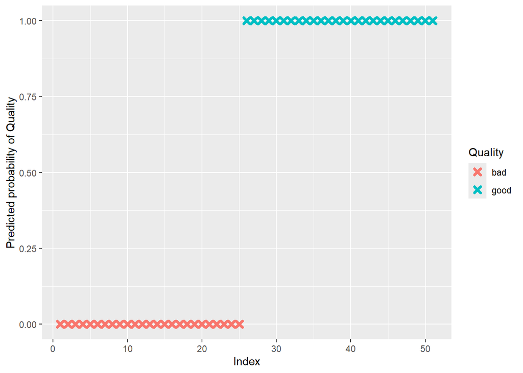

```r
predicted.data1 <- data.frame(probability.of.Quality=logistic$fitted.values,Quality=apples2$Quality)
predicted.data1 <- predicted.data1[order(predicted.data1$probability.of.Quality, decreasing=FALSE),]
predicted.data1$rank <- 1:nrow(predicted.data1)
ggplot(data=predicted.data1, aes(x=rank, y=probability.of.Quality)) +
geom_point(aes(color=Quality), alpha=1, shape=4, stroke=2) +
xlab("Index") +
ylab("Predicted probability of Quality")
```

### Prediction

```r
pdata1 <- predict(logistic,newdata=apples2,type="response" )
pdata1
```

```
##            0            1            2            3            4            5
## 1.000000e+00 1.000000e+00 2.900701e-12 1.000000e+00 1.000000e+00 2.900701e-12
##            6            7            8            9           10           11
## 1.000000e+00 1.000000e+00 2.900701e-12 2.900701e-12 2.900701e-12 1.000000e+00
##           12           13           14           15           16           17
## 2.900701e-12 1.000000e+00 1.000000e+00 1.000000e+00 2.900701e-12 1.000000e+00
##           18           19           20           21           22           23
## 2.900701e-12 1.000000e+00 2.900701e-12 1.000000e+00 2.900701e-12 2.900701e-12
##           24           25           26           27           28           29
## 2.900701e-12 2.900701e-12 1.000000e+00 2.900701e-12 2.900701e-12 2.900701e-12
##           30           31           32           33           34           35
## 2.900701e-12 1.000000e+00 1.000000e+00 2.900701e-12 1.000000e+00 2.900701e-12
##           36           37           38           39           40           41
## 1.000000e+00 1.000000e+00 1.000000e+00 1.000000e+00 2.900701e-12 1.000000e+00
##           42           43           44           45           46           47
## 2.900701e-12 2.900701e-12 1.000000e+00 1.000000e+00 1.000000e+00 2.900701e-12
##           48           49           50
## 2.900701e-12 2.900701e-12 1.000000e+00
```

### Inference

- Here the model is predicting Quality for every apple.

### Confusion matrix with model accuracy

```r
pdataF1 <- as.factor(ifelse(test=as.numeric(pdata1>0.5) == "good", yes="good", no="bad"))
pdataF1 <- factor(pdataF1, levels = levels(apples2$Quality))

confusionMatrix(pdataF1, apples2$Quality)
```

```
## Confusion Matrix and Statistics
##
##           Reference
## Prediction bad good
##       bad   25   26
##       good   0    0
##
##                Accuracy : 0.4902
##                  95% CI : (0.3475, 0.634)
##     No Information Rate : 0.5098
##     P-Value [Acc > NIR] : 0.6629
##
##                   Kappa : 0
##
##  Mcnemar's Test P-Value : 9.443e-07
##
##             Sensitivity : 1.0000
##             Specificity : 0.0000
##          Pos Pred Value : 0.4902
##          Neg Pred Value :    NaN
##              Prevalence : 0.4902
##          Detection Rate : 0.4902
##    Detection Prevalence : 1.0000
##       Balanced Accuracy : 0.5000
##
##        'Positive' Class : bad
##
```

### Inference

- We can see the models overall performance if it is correctly classifying into its related classes or not.
- Also tells us about sensitivity, specificity etc.
- The model accuracy is also shown which is 0.49, where as balanced accuracy is 0.50.